# PROJET Kit-Big-Data 2022

### Import

```python
import pandas as pd
import numpy as np
import requests
import re
from shutil import copyfileobj
from urllib import request
import os
import uuid
import xlwings as xw
import seaborn as sns
import matplotlib.pyplot as plt
```

```
<frozen importlib._bootstrap>:219: RuntimeWarning: scipy._lib.messagestream.MessageStream size changed, may indicate binary incompatibility. Expected 56 from C header, got 64 from PyObject
```

# I.Acquisition et chargement des données

## 1) Fichiers Excel des classements via la page de classement

On commence par récupérer les données grâce à request, pour les placer dans une copie locale, et nettoyer rapidement les datasets obtenus.

```python
adresse = "https://www.vendeeglobe.org/fr/classement"
demande = requests.get(adresse)
string = demande.content.decode("utf-8")
pattern = re.compile('<option value="([^<]+)">-')
date_obtenu = [match.group(1) for match in pattern.finditer(string)]
for i in date_obtenu :
    url_classement_date = f"https://www.vendeeglobe.org/download-race-data/vendeeglobe_{i}.xlsx"
    filename = f'./donnees/vendeeglobe_{i}.xlsx'
    os.makedirs(os.path.dirname(filename), exist_ok=True)
    with request.urlopen(url_classement_date) as rep, open(filename, 'wb') as file:
        copyfileobj(rep, file)
```

Ensuite

```python
def sauvegarde(fichier):
    tmp = fichier
    App = xw.App(visible=False)
    book_open = App.books.open(fichier)
    book_open.save(tmp)
    book_open.close()
    App.quit()
    return tmp

def file_to_data_df(path):
    nom_colonne = ['Rang', 'Nation/Voile', 'Skipper/Voilier', 'Heure Fr', 'Lat', 'Long', 'Cap (30 min)', 'Vitesse (30min)', 'VMG (30min)', 'Distance (30min)', 'Cap (Last rank)', 'Vitesse (Last rank)', 'VMG (Last rank)', 'Distance (Last rank)', 'Cap (24h)', 'Vitesse (24h)', 'VMG (24h)', 'Distance (24h)', 'DTF','DTL']
    indice_colonne_dodge = [0,1,2,3]
    indice_colonne_dodge_behind = 4
    data = pd.read_excel(sauvegarde(path),skiprows = indice_colonne_dodge, skipfooter = indice_colonne_dodge_behind, usecols = range(1,21),names = nom_colonne)
    data["Heure Fr"] = path[22:26] + '-' + path[26:28] + '/' + path[28:30] + "-" + data["Heure Fr"]
    data_df = pd.DataFrame(data)
    return (data_df)

def nettoye_df(df):
    df.set_index(['Rang'], inplace=True)
    df['Heure Fr'] = df['Heure Fr'].str.replace("FR\n","")
    df['Nation/Voile'] = df['Nation/Voile'].str.replace("\n","")
    df[['Skipper','Voilier']] = df['Skipper/Voilier'].str.split("\n",expand=True)
    df = df.drop(columns=['Skipper/Voilier'], axis=1)
    return(df)
```

```python
fichier = './donnees/vendeeglobe_20201110_040000.xlsx'
sauvegarde(fichier)
a = file_to_data_df(fichier)
df = nettoye_df(a)
```

On concatene les fichiers afin d'obtenir une seule DF de classement

```python
files_form = "./donnees/vendeeglobe_20201115_110000.xlsx"
df_forme = generate_df_class(files_form)
df_totale = df
for filename in os.listdir("./donnees"):
    L_concat=[]
    if filename == 'vendeeglobe_20210127_140000.xlsx':
            break
    elif filename != 'vendeeglobe_20201110_040000.xlsx' and filename!= "vendeeglobe_20201108_120200.xlsx":
        print(filename)
        sauvegarde("./donnees/" + filename)
        tmp_df = file_to_data_df("./donnees/" + filename)
        tmp_clean = nettoye_df(tmp_df)
        L_concat = [df_totale,tmp_clean]
        df_totale = pd.concat(L_concat)
```

```python
df_totale.to_pickle("./df_totale")
```

On nettoie le nouveau dataset, sur les RETs et les NL.

```python
L_indice_del = []
for k in range(len(df_totale)):
    if df_totale['Rang'].iloc[k] == "RET" or df_totale['Rang'].iloc[k] == "NL" :
        L_indice_del.append(k)
df_totale = df_totale.drop(L_indice_del,axis = 0)
```

```python
df_totale.to_pickle("./df_totale")
df_totale.head()
```

|  | Rang | Nation/Voile | Heure Fr | Lat | Long | Cap (30 min) | Vitesse (30min) | VMG (30min) | Distance (30min) | Cap (Last rank) | ... | VMG (Last rank) | Distance (Last rank) | Cap (24h) | Vitesse (24h) | VMG (24h) | Distance (24h) | DTF | DTL | Skipper | Voilier |
| --- | --- | --- | --- | --- | --- | --- | --- | --- | --- | --- | --- | --- | --- | --- | --- | --- | --- | --- | --- | --- | --- |
| 0 | 1 | FRA 79 | 2021-01/27-14:30 | 46°14.07'N | 03°41.61'W | 39° | 21.0 kts | 16.0 kts | 10.5 nm | 37° | ... | 17.4 kts | 57.2 nm | 61° | 13.9 kts | 13.9 kts | 334.3 nm | 80.5 nm | 0.0 nm | Charlie Dalin | APIVIA |
| 1 | 2 | FRA 18 | 2021-01/27-14:31 1min | 46°24.62'N | 05°11.90'W | 116° | 17.8 kts | 15.6 kts | 9.2 nm | 110° | ... | 16.9 kts | 53.3 nm | 100° | 17.2 kts | 16.9 kts | 412.1 nm | 141.5 nm | 60.9 nm | Louis Burton | Bureau Vallée 2 |
| 2 | 3 | MON 10 | 2021-01/27-14:30 | 44°31.46'N | 05°20.55'W | 130° | 18.2 kts | 3.4 kts | 9.1 nm | 113° | ... | 10.3 kts | 49.9 nm | 84° | 13.5 kts | 12.9 kts | 323.5 nm | 190.0 nm | 109.5 nm | Boris Herrmann | Seaexplorer - Yacht Club De Monaco |
| 3 | 4 | FRA 59 | 2021-01/27-14:30 | 47°24.42'N | 07°22.08'W | 103° | 17.6 kts | 17.5 kts | 8.8 nm | 102° | ... | 17.6 kts | 52.9 nm | 93° | 18.1 kts | 18.0 kts | 433.4 nm | 235.8 nm | 155.3 nm | Thomas Ruyant | LinkedOut |
| 4 | 5 | FRA 17 | 2021-01/27-14:30 | 47°43.38'N | 07°58.81'W | 98° | 18.4 kts | 18.3 kts | 9.2 nm | 98° | ... | 18.1 kts | 54.4 nm | 91° | 18.6 kts | 18.6 kts | 447.2 nm | 264.3 nm | 183.7 nm | Yannick Bestaven | Maître Coq IV |

5 rows × 21 columns

## 2) Données sur les bateaux

On récupère les données sur les voiliers, puis on les nettoie.

```python
adresse = "https://www.vendeeglobe.org/fr/glossaire"
demande = requests.get(adresse)
string = demande.content.decode("utf-8")

pattern = re.compile(r'<li>[a-zA-Z-].*</li>')
data_obtenu = [match.group(0) for match in pattern.finditer(string)]
data_obtenu.remove('<li>Espaces</li>')
data_obtenu.remove('<li>ESPACES</li>')

Liste_clean = []
Liste_indice = []
for k in range(len(data_obtenu)):
    Liste_clean.append(data_obtenu[k][4:-5])

for k in range(len(Liste_clean)):
    if Liste_clean[k][:6] == 'Numéro' or (k != 0 and Liste_clean[k] == "Architecte : Verdier" and Liste_clean[k-1] == "Surface de voiles au portant : 580 m2" ) :
            Liste_indice.append(k)

L_propre = []
n = len(Liste_indice)
for k in range(0,n-1):
    L=[]
    L_propre.append(Liste_clean[Liste_indice[k]:Liste_indice[k+1]])


L_propre[15].remove('Date de lancement : 01 Janvier 1970')
L_propre

for k in range(len(L_propre)):
    if L_propre[k][1][:6]!= 'Ancien':
        L_propre[k].insert(1,"Anciens noms du bateau : Pas d'anciens noms")


colonnes = ['Numéro de voile','Anciens noms du bateau','Architecte','Chantier','Date de lancement','Longueur','Largeur',"Tirant d'eau",'Déplacement','Nombre de dérives','Hauteur mât','Voile quille','Surface de voile au près','Surface de voiles au portant']
Value_missing = ["Anciens noms du bateau : Pas d'anciens noms",'Architecte : Verdier','Chantier : Persico','Date de lancement : 03 Septembre 2019','Longueur : 18,28 m','Largeur : 5,85 m',"Tirant d'eau : 4,50 m",'Déplacement (poids) : 8 t','Nombre de dérives : foils','Hauteur mât : 29 m','Voile quille : acier forgé','Surface de voiles au près : 350 m2','Surface de voiles au portant : 560 m2']
df = pd.DataFrame(L_propre, columns = colonnes)
df_clean = df.set_index(['Numéro de voile']).drop('Architecte : Verdier')
df_clean.loc['Numéro de voile : Inconnu'] = Value_missing
df_clean["Anciens noms du bateau"] = df_clean["Anciens noms du bateau"].str.replace("Anciens noms du bateau :","")
df_clean["Architecte"] = df_clean["Architecte"].str.replace("Architecte :","")
df_clean["Chantier"] = df_clean["Chantier"].str.replace("Chantier:","")
df_clean["Date de lancement"] = df_clean["Date de lancement"].str.replace("Date de lancement :","")
df_clean["Longueur"] = df_clean["Longueur"].str.replace("Longueur :","")
df_clean["Largeur"] = df_clean["Largeur"].str.replace("Largeur :","")
df_clean["Tirant d'eau"] = df_clean["Tirant d'eau"].str.replace("Tirant d'eau :","")
df_clean["Déplacement"] = df_clean["Déplacement"].str.replace("Déplacement :","")
df_clean["Nombre de dérives"] = df_clean["Nombre de dérives"].str.replace("Nombre de dérives :","")
df_clean["Hauteur mât"] = df_clean["Hauteur mât"].str.replace("Hauteur mât :","")
df_clean["Voile quille"] = df_clean["Voile quille"].str.replace("Voile quille :","")
df_clean["Surface de voile au près"] = df_clean["Surface de voile au près"].str.replace("Surface de voiles au près :","")
df_clean["Surface de voiles au portant"] = df_clean["Surface de voiles au portant"].str.replace("Surface de voiles au portant :","")
df_clean.index = df_clean.index.str.replace("Numéro de voile :","")
df_clean["Chantier"] = df_clean["Chantier"].str.replace("Chantier :","")
df_clean["Déplacement"] = df_clean["Déplacement"].str.replace(r"Déplacement (poids) :","")
df_clean.head()
```

| Numéro de voile | Anciens noms du bateau | Architecte | Chantier | Date de lancement | Longueur | Largeur | Tirant d'eau | Déplacement | Nombre de dérives | Hauteur mât | Voile quille | Surface de voile au près | Surface de voiles au portant |
| --- | --- | --- | --- | --- | --- | --- | --- | --- | --- | --- | --- | --- | --- |
| FRA 56 | No Way Back, Vento di Sardegna | VPLP/Verdier | Persico Marine | 01 Août 2015 | 18,28 m | 5,85 m | 4,50 m | Déplacement (poids) : 7 t | foils | 29 m | monotype | 320 m2 | 570 m2 |
| FRA 49 | Gitana Eighty, Synerciel, Newrest-Matmut | Bruce Farr Design | Southern Ocean Marine (Nouvelle Zélande) | 08 Mars 2007 | 18,28m | 5,80m | 4,50m | Déplacement (poids) : 9t | 2 | 28m | acier forgé | 280 m2 | 560 m2 |
| FRA72 | Famille Mary-Etamine du Lys, Initiatives Coeu... | Marc Lombard | MAG France | 01 Mars 1998 | 18,28m | 5,54m | 4,50m | Déplacement (poids) : 9t | 2 | 29 m | acier | 260 m2 | 580 m2 |
| 17 | Safran 2 - Des Voiles et Vous | Verdier - VPLP | CDK Technologies | 12 Mars 2015 | 18,28 m | 5,80 m | 4,50 m | Déplacement (poids) : 8 t | foils | 29 m | acier mécano soudé | 310 m2 | 550 m2 |
| 08 | Pas d'anciens noms | VPLP | CDK Technologies | 18 Août 2018 | 18,28 m | 5,85 m | 4,50 m | Déplacement (poids) : 8t | foils | 29 m | acier | 320 m2 | 600 m2 |

Pour le moment cette DataFrame nous suffit, mais on sent bien qu'il faudra effectuer des opérations si l'on souhaite l'utiliser pour des calculs.

```python
df_bateaux = df_clean
df_bateaux.to_pickle("./df_bateaux.pkl")
```

# II- Préparation des données

## 1)Préparation des données relatives aux classements

On adapte la DF à un format convenable pour l'utiliser dans de futur calcul

```python
df_calcul = pd.read_pickle("./df_totale")
df_calcul["Vitesse (30min)"]=df_calcul["Vitesse (30min)"].str.replace("kts","")
df_calcul["Vitesse (24h)"]=df_calcul["Vitesse (24h)"].str.replace("kts","")
df_calcul["Vitesse (Last rank)"]=df_calcul["Vitesse (Last rank)"].str.replace("kts","")
df_calcul["VMG (30min)"]=df_calcul["VMG (30min)"].str.replace("kts","")
df_calcul["VMG (24h)"]=df_calcul["VMG (24h)"].str.replace("kts","")
df_calcul["VMG (Last rank)"]=df_calcul["VMG (Last rank)"].str.replace("kts","")
df_calcul["Distance (30min)"]=df_calcul["Distance (30min)"].str.replace("nm","")
df_calcul["Distance (24h)"]=df_calcul["Distance (24h)"].str.replace("nm","")
df_calcul["Distance (Last rank)"]=df_calcul["Distance (Last rank)"].str.replace("nm","")
df_calcul["DTF"]=df_calcul["DTF"].str.replace("nm","")
df_calcul["DTL"]=df_calcul["DTL"].str.replace("nm","")
colonnes_calcul = {"Vitesse (30min)" : "Vitesse (30min) en kts","VMG (30min)" : "VMG (30min) en kts","Distance (30min)" : "Distance (30min) en nm","Vitesse (24h)" : "Vitesse (24h) en kts","VMG (24h)" : "VMG (24h) en kts","Distance (24h)" : "Distance (24h) en nm","Vitesse (Last rank)" : "Vitesse (Last rank) en kts","VMG (Last rank)" : "VMG (Last rank) en kts","Distance (Last rank)" : "Distance (Last rank) en nm","DTF" : "DTF en nm", "DTL":"DTL en nm"}
df_calcul = df_calcul.rename(columns = colonnes_calcul)
df_calcul.to_pickle("./vendeeglobe_20201110_040000_calcul")
df_calcul.head()
```

|  | Rang | Nation/Voile | Heure Fr | Lat | Long | Cap (30 min) | Vitesse (30min) en kts | VMG (30min) en kts | Distance (30min) en nm | Cap (Last rank) | ... | VMG (Last rank) en kts | Distance (Last rank) en nm | Cap (24h) | Vitesse (24h) en kts | VMG (24h) en kts | Distance (24h) en nm | DTF en nm | DTL en nm | Skipper | Voilier |
| --- | --- | --- | --- | --- | --- | --- | --- | --- | --- | --- | --- | --- | --- | --- | --- | --- | --- | --- | --- | --- | --- |
| 0 | 1 | FRA 79 | 2021-01/27-14:30 | 46°14.07'N | 03°41.61'W | 39° | 21.0 | 16.0 | 10.5 | 37° | ... | 17.4 | 57.2 | 61° | 13.9 | 13.9 | 334.3 | 80.5 | 0.0 | Charlie Dalin | APIVIA |
| 1 | 2 | FRA 18 | 2021-01/27-14:31 1min | 46°24.62'N | 05°11.90'W | 116° | 17.8 | 15.6 | 9.2 | 110° | ... | 16.9 | 53.3 | 100° | 17.2 | 16.9 | 412.1 | 141.5 | 60.9 | Louis Burton | Bureau Vallée 2 |
| 2 | 3 | MON 10 | 2021-01/27-14:30 | 44°31.46'N | 05°20.55'W | 130° | 18.2 | 3.4 | 9.1 | 113° | ... | 10.3 | 49.9 | 84° | 13.5 | 12.9 | 323.5 | 190.0 | 109.5 | Boris Herrmann | Seaexplorer - Yacht Club De Monaco |
| 3 | 4 | FRA 59 | 2021-01/27-14:30 | 47°24.42'N | 07°22.08'W | 103° | 17.6 | 17.5 | 8.8 | 102° | ... | 17.6 | 52.9 | 93° | 18.1 | 18.0 | 433.4 | 235.8 | 155.3 | Thomas Ruyant | LinkedOut |
| 4 | 5 | FRA 17 | 2021-01/27-14:30 | 47°43.38'N | 07°58.81'W | 98° | 18.4 | 18.3 | 9.2 | 98° | ... | 18.1 | 54.4 | 91° | 18.6 | 18.6 | 447.2 | 264.3 | 183.7 | Yannick Bestaven | Maître Coq IV |

5 rows × 21 columns

## 2) Extraction des caractéristiques techniques de chacun des voilier

On fait la même chose avec la DataFrame de bateaux.

```python
df_bateaux_caracteristiques = pd.read_pickle("./df_bateaux.pkl")
titre = {'Longueur':'Longueur en mètres','Largeur' : "Largeur en mètres","Tirant d'eau" : "Tirant d'eau en mètres","Déplacement" : "Déplacement (poids) en tonnes","Hauteur mât":"Hauteur mât en mètres","Surface de voile au près":"Surface de voile au près en m²","Surface de voiles au portant" : "Surface de voiles au portant en m²"}
df_bateaux_caracteristiques["Chantier"] = df_bateaux_caracteristiques["Chantier"].str.replace("Chantier :","")
df_bateaux_caracteristiques["Longueur"] = df_bateaux_caracteristiques["Longueur"].str.replace("m","")
df_bateaux_caracteristiques["Largeur"] = df_bateaux_caracteristiques["Largeur"].str.replace("m","")
df_bateaux_caracteristiques["Tirant d'eau"] = df_bateaux_caracteristiques["Tirant d'eau"].str.replace("m","")
df_bateaux_caracteristiques["Déplacement"] = df_bateaux_caracteristiques["Déplacement"].str.replace("Déplacement (poids) :","")
df_bateaux_caracteristiques["Déplacement"] = df_bateaux_caracteristiques["Déplacement"].str.replace("t","")
df_bateaux_caracteristiques["Hauteur mât"] = df_bateaux_caracteristiques["Hauteur mât"].str.replace("m","")
df_bateaux_caracteristiques["Surface de voile au près"] = df_bateaux_caracteristiques["Surface de voile au près"].str.replace("m2","")
df_bateaux_caracteristiques["Surface de voile au près"] = df_bateaux_caracteristiques["Surface de voile au près"].str.replace("m²","")
df_bateaux_caracteristiques["Surface de voiles au portant"] = df_bateaux_caracteristiques["Surface de voiles au portant"].str.replace("m2","")
df_bateaux_caracteristiques["Surface de voiles au portant"] = df_bateaux_caracteristiques["Surface de voiles au portant"].str.replace("m²","")
df_bateaux_caracteristiques = df_bateaux_caracteristiques.rename(columns = titre )
df_bateaux_caracteristiques.to_pickle("./df_bateaux_caractéristiques")
df_bateaux_caracteristiques.head()
```

| Numéro de voile | Anciens noms du bateau | Architecte | Chantier | Date de lancement | Longueur en mètres | Largeur en mètres | Tirant d'eau en mètres | Déplacement (poids) en tonnes | Nombre de dérives | Hauteur mât en mètres | Voile quille | Surface de voile au près en m² | Surface de voiles au portant en m² |
| --- | --- | --- | --- | --- | --- | --- | --- | --- | --- | --- | --- | --- | --- |
| FRA 56 | No Way Back, Vento di Sardegna | VPLP/Verdier | Persico Marine | 01 Août 2015 | 18,28 | 5,85 | 4,50 | Déplacemen (poids) : 7 | foils | 29 | monotype | 320 | 570 |
| FRA 49 | Gitana Eighty, Synerciel, Newrest-Matmut | Bruce Farr Design | Southern Ocean Marine (Nouvelle Zélande) | 08 Mars 2007 | 18,28 | 5,80 | 4,50 | Déplacemen (poids) : 9 | 2 | 28 | acier forgé | 280 | 560 |
| FRA72 | Famille Mary-Etamine du Lys, Initiatives Coeu... | Marc Lombard | MAG France | 01 Mars 1998 | 18,28 | 5,54 | 4,50 | Déplacemen (poids) : 9 | 2 | 29 | acier | 260 | 580 |
| 17 | Safran 2 - Des Voiles et Vous | Verdier - VPLP | CDK Technologies | 12 Mars 2015 | 18,28 | 5,80 | 4,50 | Déplacemen (poids) : 8 | foils | 29 | acier mécano soudé | 310 | 550 |
| 08 | Pas d'anciens noms | VPLP | CDK Technologies | 18 Août 2018 | 18,28 | 5,85 | 4,50 | Déplacemen (poids) : 8 | foils | 29 | acier | 320 | 600 |

On reset l'index pour mettre en place les noms de voilier afin de merge dessus

## 3) Rapprochement des données des voiliers avec celle des classements.

Pour cela, on va merge sur les noms de voiliers

```python
Map = {"Time For Oceans" : " FRA 92","Pure - Best Western Hotels and Resorts" : " FRA 49","Campagne de France" : " FRA50","Groupe Sétin" : " FRA 71","One Planet One Ocean" : " ESP 33","Medallia" : " GBR77","Bureau Vallée 2" : " 18","DMG MORI Global One" : " JPN 11","La Fabrique" : " SUI07","Stark" : " FIN222","Charal" : " 08","Banque Populaire X" : " FRA30","TSE - 4myplanet" : " FRA72","L'Occitane en Provence" : " 2","V And B Mayenne" : " FRA53","OMIA - Water Family" : " FRA09","Yes we Cam !" : " 001","Prysmian Group" : " ITA 34","Groupe APICIL" : " FRA1000","Maître Coq IV" : " 17", "LinkedOut" : "Inconnu","Seaexplorer - Yacht Club De Monaco" : " 16","Compagnie du lit - Jiliti" : " FRA83","APIVIA" : " FRA 79","La Mie Câline - Artisans Artipôle" : " FRA 14","Merci" : " 69","MACSF" : " FRA 27","Newrest - Art et Fenetres" : " FRA 56","Initiatives - Coeur" : " FRA109","ARKEA PAPREC" : " 4", "HUGO BOSS" : " GBR 99","PRB" : " FRA 85","CORUM L'Épargne" : " FRA 6", "Hugo Boss" : " GBR 99"}

df_calcul["Voilier"] = df_calcul["Voilier"].map(Map)
```

```python
L = []
L_tot = [k for k in range(len(df_calcul))]
for k in range(len(df_calcul)):
    if df_calcul["Voilier"].iloc[k] == " FRA 6":
        L.append(k)

for k in range(len(L)):
    L_tot.remove(L[k])
```

```python
df_bateaux_caracteristiques = df_bateaux_caracteristiques.reset_index()
df_bateaux_caracteristiques = df_bateaux_caracteristiques.rename(columns = {'Numéro de voile':'Voilier'})
```

```python
df_calcul_2 = df_calcul.iloc[L_tot]
df_fusion = pd.merge(left = df_calcul_2,right = df_bateaux_caracteristiques, left_on='Voilier', right_on='Voilier')
df_fusion.head()
```

|  | Rang | Nation/Voile | Heure Fr | Lat | Long | Cap (30 min) | Vitesse (30min) en kts | VMG (30min) en kts | Distance (30min) en nm | Cap (Last rank) | ... | Date de lancement | Longueur en mètres | Largeur en mètres | Tirant d'eau en mètres | Déplacement (poids) en tonnes | Nombre de dérives | Hauteur mât en mètres | Voile quille | Surface de voile au près en m² | Surface de voiles au portant en m² |
| --- | --- | --- | --- | --- | --- | --- | --- | --- | --- | --- | --- | --- | --- | --- | --- | --- | --- | --- | --- | --- | --- |
| 0 | 1 | FRA 79 | 2021-01/27-14:30 | 46°14.07'N | 03°41.61'W | 39° | 21.0 | 16.0 | 10.5 | 37° | ... | 05 Août 2019 | 18,28 | 5,85 | 4,50 | Déplacemen (poids) : 8 | foils | 29 | acier | 350 | 560 |
| 1 | 2 | FRA 79 | 2020-11/08-17:00 | 46°17.46'N | 02°31.45'W | 262° | 24.8 | 22.8 | 12.4 | 357° | ... | 05 Août 2019 | 18,28 | 5,85 | 4,50 | Déplacemen (poids) : 8 | foils | 29 | acier | 350 | 560 |
| 2 | 2 | FRA 79 | 2020-11/08-18:30 | 46°15.92'N | 03°21.99'W | 266° | 20.1 | 17.3 | 10.1 | 267° | ... | 05 Août 2019 | 18,28 | 5,85 | 4,50 | Déplacemen (poids) : 8 | foils | 29 | acier | 350 | 560 |
| 3 | 5 | FRA 79 | 2020-11/08-22:30 | 46°10.33'N | 04°47.42'W | 263° | 9.3 | 7.6 | 4.6 | 264° | ... | 05 Août 2019 | 18,28 | 5,85 | 4,50 | Déplacemen (poids) : 8 | foils | 29 | acier | 350 | 560 |
| 4 | 17 | FRA 79 | 2020-11/09-05:30 | 46°35.71'N | 07°14.42'W | 288° | 15.9 | 1.6 | 7.9 | 283° | ... | 05 Août 2019 | 18,28 | 5,85 | 4,50 | Déplacemen (poids) : 8 | foils | 29 | acier | 350 | 560 |

5 rows × 34 columns

```python
df_fusion.to_pickle("./fusion.pkl")
```

## Observons les différents paramètres de bateaux qui sont souvent dans le top 3 lors de la course

On commence avec la largeur des bateaux, la longueur est toujours la même, on ne s'intéresse pas à ce paramètre.

### LARGEUR

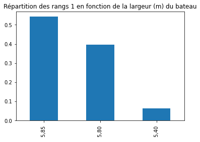

```python
repart_bateaux_longueur = df_fusion[df_fusion["Rang"]=="1"]["Largeur en mètres"].value_counts()
Somme_totale = repart_bateaux_longueur.sum()
valeurs = repart_bateaux_longueur/Somme_totale
valeurs.plot(title = 'Répartition des rangs 1 en fonction de la largeur (m) du bateau',kind = 'bar')
```

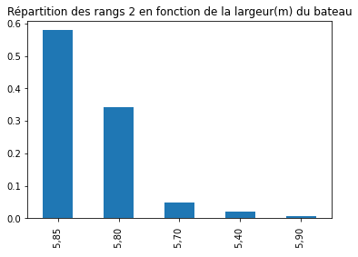

```python
repart_bateaux_longueur = df_fusion[df_fusion["Rang"]=="2"]["Largeur en mètres"].value_counts()
Somme_totale = repart_bateaux_longueur.sum()
valeurs = repart_bateaux_longueur/Somme_totale
valeurs.plot(title = 'Répartition des rangs 2 en fonction de la largeur(m) du bateau',kind = 'bar')
```

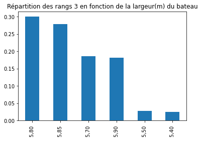

```python
repart_bateaux_longueur = df_fusion[df_fusion["Rang"]=="3"]["Largeur en mètres"].value_counts()
Somme_totale = repart_bateaux_longueur.sum()
valeurs = repart_bateaux_longueur/Somme_totale
valeurs.plot(title = 'Répartition des rangs 3 en fonction de la largeur(m) du bateau',kind = 'bar')
```

La plupart des bateaux dans le top 3 présente souvent une largeur proche de 5.80 - 5.85m. Cependant, on ne peut rien affirmer vis à vis de la corrélation entre le rang et ce paramètre. Il faut faire la différence entre causalité et corrélation

## Hauteur du mât

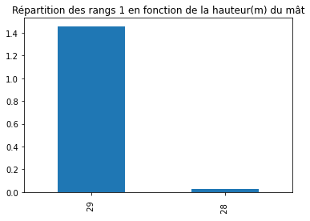

```python
repart_bateaux_hauteur = df_fusion[df_fusion["Rang"]=="1"]["Hauteur mât en mètres"].value_counts()
Somme_totale = repart_bateaux_longueur.sum()
valeurs = repart_bateaux_hauteur/Somme_totale
valeurs.plot(title = 'Répartition des rangs 1 en fonction de la hauteur(m) du mât',kind = 'bar')
```

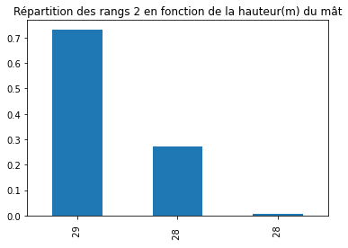

```python
repart_bateaux_hauteur = df_fusion[df_fusion["Rang"]=="2"]["Hauteur mât en mètres"].value_counts()
Somme_totale = repart_bateaux_longueur.sum()
valeurs = repart_bateaux_hauteur/Somme_totale
valeurs.plot(title = 'Répartition des rangs 2 en fonction de la hauteur(m) du mât',kind = 'bar')
```

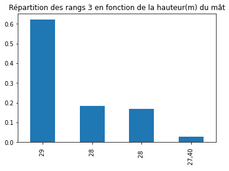

```python
repart_bateaux_hauteur = df_fusion[df_fusion["Rang"]=="3"]["Hauteur mât en mètres"].value_counts()
Somme_totale = repart_bateaux_longueur.sum()
valeurs = repart_bateaux_hauteur/Somme_totale
valeurs.plot(title = 'Répartition des rangs 3 en fonction de la hauteur(m) du mât',kind = 'bar')
```

Ici, la hauteur du mat la plus présente dans le top 3 est bien entendu celle de 29m. Encore une fois, nous ne pouvons rien vraiment affirmer

## Nombre de dérives

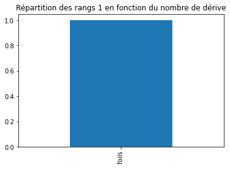

```python
repart_bateaux_dérive = df_fusion[df_fusion["Rang"]=="1"]["Nombre de dérives"].value_counts()
Somme_totale = repart_bateaux_dérive.sum()
valeurs = repart_bateaux_dérive/Somme_totale
valeurs.plot(title = 'Répartition des rangs 1 en fonction du nombre de dérive',kind = 'bar')
```

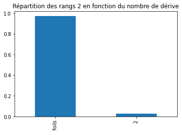

```python
repart_bateaux_dérive = df_fusion[df_fusion["Rang"]=="2"]["Nombre de dérives"].value_counts()
Somme_totale = repart_bateaux_dérive.sum()
valeurs = repart_bateaux_dérive/Somme_totale
valeurs.plot(title = 'Répartition des rangs 2 en fonction du nombre de dérive',kind = 'bar')
```

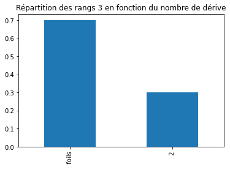

```python
repart_bateaux_dérive = df_fusion[df_fusion["Rang"]=="3"]["Nombre de dérives"].value_counts()
Somme_totale = repart_bateaux_dérive.sum()
valeurs = repart_bateaux_dérive/Somme_totale
valeurs.plot(title = 'Répartition des rangs 3 en fonction du nombre de dérive',kind = 'bar')
```

A priori les foils ont l'air plutot utile, mais encore une fois cette impression n'est en rien justifiée, même si on imagine bien qu'un bon foil permet en effet à un bateau d'aller plus vite en diminuant les frottements. Il faut pousser l'analyse plus loin si l'on souhaite démontrer cela.

## Voile quille

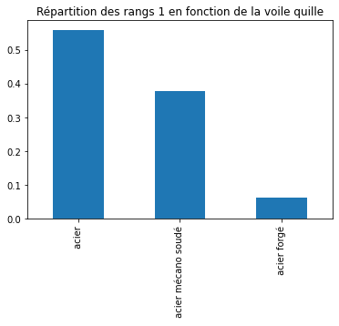

```python
repart_bateaux_voile = df_fusion[df_fusion["Rang"]=="1"]["Voile quille"].value_counts()
Somme_totale = repart_bateaux_voile.sum()
valeurs = repart_bateaux_voile/Somme_totale
valeurs.plot(title = 'Répartition des rangs 1 en fonction de la voile quille',kind = 'bar')
```

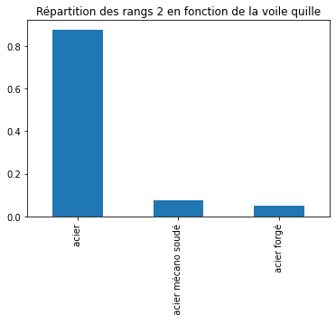

```python
repart_bateaux_voile = df_fusion[df_fusion["Rang"]=="2"]["Voile quille"].value_counts()
Somme_totale = repart_bateaux_voile.sum()
valeurs = repart_bateaux_voile/Somme_totale
valeurs.plot(title = 'Répartition des rangs 2 en fonction de la voile quille',kind = 'bar')
```

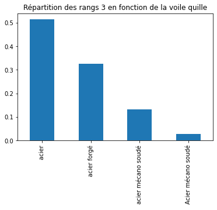

```python
repart_bateaux_voile = df_fusion[df_fusion["Rang"]=="3"]["Voile quille"].value_counts()
Somme_totale = repart_bateaux_voile.sum()
valeurs = repart_bateaux_voile/Somme_totale
valeurs.plot(title = 'Répartition des rangs 3 en fonction de la voile quille',kind = 'bar')
```

L'acier est prédominant dans le TOP 3.

## Surface de voile au près en m²

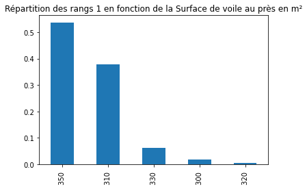

```python
repart_bateaux_surface = df_fusion[df_fusion["Rang"]=="1"]["Surface de voile au près en m²"].value_counts()
Somme_totale = repart_bateaux_surface.sum()
valeurs = repart_bateaux_surface/Somme_totale
valeurs.plot(title = 'Répartition des rangs 1 en fonction de la Surface de voile au près en m²',kind = 'bar')
```

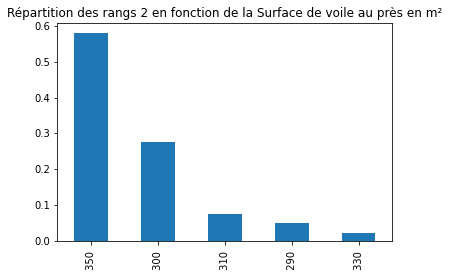

```python
repart_bateaux_surface = df_fusion[df_fusion["Rang"]=="2"]["Surface de voile au près en m²"].value_counts()
Somme_totale = repart_bateaux_surface.sum()
valeurs = repart_bateaux_surface/Somme_totale
valeurs.plot(title = 'Répartition des rangs 2 en fonction de la Surface de voile au près en m²',kind = 'bar')
```

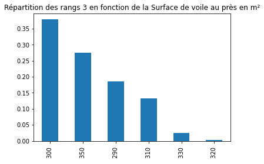

```python
repart_bateaux_surface = df_fusion[df_fusion["Rang"]=="3"]["Surface de voile au près en m²"].value_counts()
Somme_totale = repart_bateaux_surface.sum()
valeurs = repart_bateaux_surface/Somme_totale
valeurs.plot(title = 'Répartition des rangs 3 en fonction de la Surface de voile au près en m²',kind = 'bar')
```

Ici les résultats sont intéressants, les deux surfaces les plus présentes semblent opposées. En effet 350 m² est une grande voile, en revanche 300m² est bien plus petit. Quel facteur joue ici ? Est-ce une relation simple de bateau léger avec une petite surface de voile et bateau lourd avec une grosse surface de voile ?

## Déplacement (poids) en tonnes

```python
df_fusion["Déplacement (poids) en tonnes"]=df_fusion["Déplacement (poids) en tonnes"].str.replace("\\(\\)","")
df_fusion["Déplacement (poids) en tonnes"]=df_fusion["Déplacement (poids) en tonnes"].str.replace("placemen","")
df_fusion["Déplacement (poids) en tonnes"]=df_fusion["Déplacement (poids) en tonnes"].str.replace("Dé","")
df_fusion["Déplacement (poids) en tonnes"]=df_fusion["Déplacement (poids) en tonnes"].str.replace(":","")
```

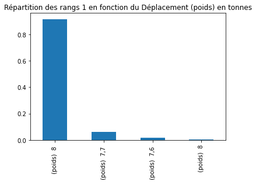

```python
repart_bateaux_déplacement = df_fusion[df_fusion["Rang"]=="1"]["Déplacement (poids) en tonnes"].value_counts()
Somme_totale = repart_bateaux_déplacement.sum()
valeurs = repart_bateaux_déplacement/Somme_totale
valeurs.plot(title = 'Répartition des rangs 1 en fonction du Déplacement (poids) en tonnes',kind = 'bar')
```

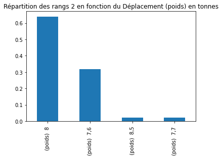

```python
repart_bateaux_déplacement = df_fusion[df_fusion["Rang"]=="2"]["Déplacement (poids) en tonnes"].value_counts()
Somme_totale = repart_bateaux_déplacement.sum()
valeurs = repart_bateaux_déplacement/Somme_totale
valeurs.plot(title = 'Répartition des rangs 2 en fonction du Déplacement (poids) en tonnes',kind = 'bar')
```

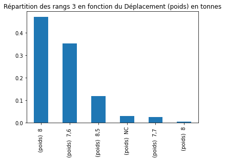

```python
repart_bateaux_déplacement = df_fusion[df_fusion["Rang"]=="3"]["Déplacement (poids) en tonnes"].value_counts()
Somme_totale = repart_bateaux_déplacement.sum()
valeurs = repart_bateaux_déplacement/Somme_totale
valeurs.plot(title = 'Répartition des rangs 3 en fonction du Déplacement (poids) en tonnes',kind = 'bar')
```

8t semblent la valeur la plus présente dans le top3

## Surface de voiles au portant en m²

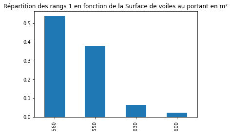

```python
repart_bateaux_portant = df_fusion[df_fusion["Rang"]=="1"]["Surface de voiles au portant en m²"].value_counts()
Somme_totale = repart_bateaux_portant.sum()
valeurs = repart_bateaux_portant/Somme_totale
valeurs.plot(title = 'Répartition des rangs 1 en fonction de la Surface de voiles au portant en m²',kind = 'bar')
```

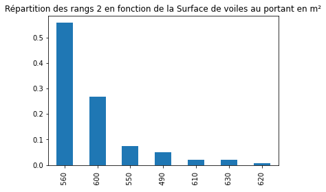

```python
repart_bateaux_portant = df_fusion[df_fusion["Rang"]=="2"]["Surface de voiles au portant en m²"].value_counts()
Somme_totale = repart_bateaux_portant.sum()
valeurs = repart_bateaux_portant/Somme_totale
valeurs.plot(title = 'Répartition des rangs 2 en fonction de la Surface de voiles au portant en m²',kind = 'bar')
```

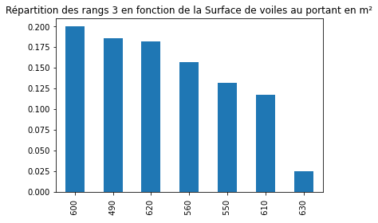

```python
repart_bateaux_portant = df_fusion[df_fusion["Rang"]=="3"]["Surface de voiles au portant en m²"].value_counts()
Somme_totale = repart_bateaux_portant.sum()
valeurs = repart_bateaux_portant/Somme_totale
valeurs.plot(title = 'Répartition des rangs 3 en fonction de la Surface de voiles au portant en m²',kind = 'bar')
```

Les valeurs les plus présentes sont 600 et 560.

On observe les distributions des différents paramètres par rapport aux bateaux étant dans le top3. Des relations semblent apparaître, mais nous n'avons pas faits une analyse précise pour les vérifier.

# III- Analyses et story telling

## 1) Corrélation et régression linéaire entre le classement (rang) et la vitesse utile (VMG) des voiliers.

On cherche la corrélation entre le classement et la vitesse utile.

```python
from sklearn.feature_selection import r_regression
df_fusion_3 = pd.read_pickle("./fusion.pkl")
df_fus = df_fusion_3[["Rang",'VMG (30min) en kts','VMG (Last rank) en kts','VMG (24h) en kts']]
df_fus["Rang"] = df_fus["Rang"].apply(lambda x: float(x))
df_fus['VMG (30min) en kts'] = df_fus['VMG (30min) en kts'].apply(lambda x: float(x))
df_fus['VMG (Last rank) en kts'] = df_fus['VMG (Last rank) en kts'].apply(lambda x: float(x))
df_fus['VMG (24h) en kts'] = df_fus['VMG (24h) en kts'].apply(lambda x: float(x))

rang_array = df_fus["Rang"].to_numpy()

lastrank_array = df_fus['VMG (Last rank) en kts'].to_numpy()
lastrank_array = lastrank_array.reshape(-1,1)
minutes_array = df_fus['VMG (30min) en kts'].to_numpy()
minutes_array = minutes_array.reshape(-1,1)
day_array = df_fus['VMG (24h) en kts'].to_numpy()
day_array =day_array.reshape(-1,1)


last = r_regression(lastrank_array,rang_array)
trente = r_regression(minutes_array,rang_array)
day = r_regression(day_array,rang_array)

print("Le coefficient de corrélation entre le rang et la VMG des 30 dernières minutes est:",trente)
print("Le coefficient de corrélation entre le rang et la VMG des 24 dernières heures est:",day)
print("Le coefficient de corrélation entre le rang et la VMG du dernier classement:",last)
```

```
Le coefficient de corrélation entre le rang et la VMG des 30 dernières minutes est: [-0.27805189]
Le coefficient de corrélation entre le rang et la VMG des 24 dernières heures est: [-0.36235815]
Le coefficient de corrélation entre le rang et la VMG du dernier classement: [-0.30350603]
```

La corrélation la plus importante est celle concernant la VMG des dernières 24h. On comprend bien que la vitesse des dernières 24h est celle qui porte le plus d'information utile pour prédire le rang. Les autres classements ont la VMG sur 30 minutes ou 3h environ. Il y a forcément moins d'information dedans.

On fait aussi une corrélation sur les moyennes des rangs et des vitesses par concurrents afin de pouvoir visualiser quelques points. De plus, on peut vérifier le résultat que la corrélation des moyennes n'est pas égale à la corrélation sur les points.

```python
df_fusion_3["Rang"] = df_fusion_3["Rang"].apply(lambda x: float(x))
df_fusion_3['VMG (30min) en kts'] = df_fusion_3['VMG (30min) en kts'].apply(lambda x: float(x))
df_fusion_3['VMG (Last rank) en kts'] = df_fusion_3['VMG (Last rank) en kts'].apply(lambda x: float(x))
df_fusion_3['VMG (24h) en kts'] = df_fusion_3['VMG (24h) en kts'].apply(lambda x: float(x))

df_fusion_3_calcul = df_fusion_3
df_fusion_3_calcul = df_fusion_3_calcul[['Skipper',"Rang",'VMG (30min) en kts','VMG (Last rank) en kts','VMG (24h) en kts']].groupby(['Skipper']).mean(["Rang",'VMG (30min) en kts','VMG (Last rank) en kts','VMG (24h) en kts' ])
```

```python
df_fusion_3_calcul.head()
```

| Skipper | Rang | VMG (30min) en kts | VMG (Last rank) en kts | VMG (24h) en kts |
| --- | --- | --- | --- | --- |
| Alan Roura | 16.316008 | 11.147817 | 11.111227 | 10.898545 |
| Alex Thomson | 7.425806 | 11.101935 | 11.152258 | 10.989032 |
| Alexia Barrier | 25.124740 | 9.488150 | 9.521830 | 9.303742 |
| Ari Huusela | 26.388773 | 9.411019 | 9.382744 | 9.257588 |
| Armel Tripon | 16.345114 | 12.258004 | 12.261538 | 12.097297 |

```
Le coefficient de corrélation de pearson pour ces données vaut : [-0.86355877]
```

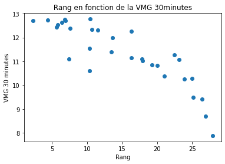

```python
rang_array = df_fusion_3_calcul["Rang"].to_numpy()
minutes_array = df_fusion_3_calcul['VMG (30min) en kts'].to_numpy()
minutes_array = minutes_array.reshape(-1,1)
trente = r_regression(minutes_array,rang_array)

print("Le coefficient de corrélation de pearson pour ces données vaut :",trente)


plt.figure()
plt.scatter(df_fusion_3_calcul['Rang'], df_fusion_3_calcul['VMG (30min) en kts'])
plt.title(' Rang en fonction de la VMG 30minutes ')
plt.xlabel('Rang')
plt.ylabel('VMG 30 minutes')
plt.show()
```

Un Bateau qui en moyenne possède une bonne VMG des 30 dernières minutes est presque garantie d'avoir un classement élevé. Ici on a de la causalité. Ce résultat n'est pas du tout choquant. Les autres graphiques sont semblables, on passe vite dessus.

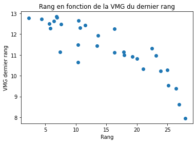

```python
plt.figure()
plt.scatter(df_fusion_3_calcul['Rang'], df_fusion_3_calcul['VMG (Last rank) en kts'])
plt.title(' Rang en fonction de la VMG du dernier rang ')
plt.xlabel('Rang')
plt.ylabel('VMG dernier rang')
plt.show()
```

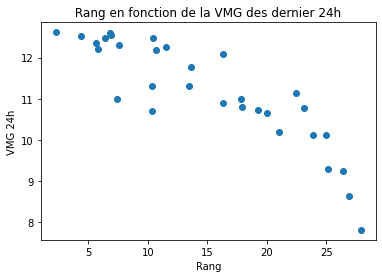

```python
plt.figure()
plt.scatter(df_fusion_3_calcul['Rang'], df_fusion_3_calcul['VMG (24h) en kts'])
plt.title(' Rang en fonction de la VMG des dernier 24h ')
plt.xlabel('Rang')
plt.ylabel('VMG 24h')
plt.show()
```

Les courbes sont très similaires (cf explication ci-dessus), et on voit bien la corrélation négative qui existe.

## Régression linéaire

On va se concentrer sur les données des dernières 24H, elles présentent le coefficient de corrélation le plus élévé.

```
[-0.8139869]
[24.41220603]
```

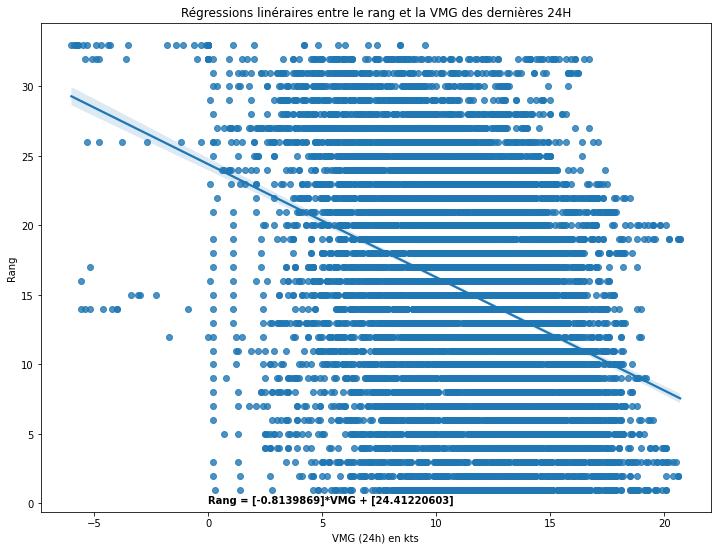

```python
from sklearn import linear_model
regr = linear_model.LinearRegression()
X = df_fus['VMG (24h) en kts'].values.reshape(-1,1)
y = df_fus["Rang"].values.reshape(-1,1)
regr.fit(X, y)
print(regr.coef_[0])
print(regr.intercept_)



fig, ax = plt.subplots(1, 1, figsize=(12, 9))
sns.regplot(x = 'VMG (24h) en kts', y = "Rang", data = df_fus )
plt.text(0,0,f"Rang = {regr.coef_[0]}*VMG + {regr.intercept_}" , horizontalalignment='left', size='medium', color='black', weight='semibold')
ax.set_title('Régressions linéraires entre le rang et la VMG des dernières 24H')
```

Ce résultat n'est pas très agréable à l'oeil. On va ainsi utiliser la moyenne des points pour obtenir un résultat plus beau.

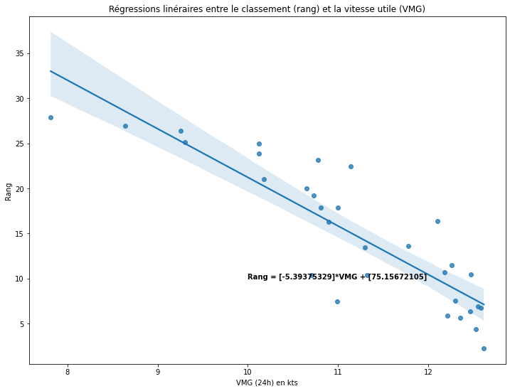

```python
from sklearn import linear_model
regr = linear_model.LinearRegression()
X = df_fusion_3_calcul['VMG (24h) en kts'].values.reshape(-1,1)
y = df_fusion_3_calcul["Rang"].values.reshape(-1,1)
regr.fit(X, y)



fig, ax = plt.subplots(1, 1, figsize=(12, 9))
sns.regplot(x = 'VMG (24h) en kts', y = "Rang", data = df_fusion_3_calcul )
plt.text(10,10,f"Rang = {regr.coef_[0]}*VMG + {regr.intercept_}" , horizontalalignment='left', size='medium', color='black', weight='semibold')
ax.set_title('Régressions linéraires entre le classement (rang) et la vitesse utile (VMG)')
```

On a maintenant les coefficients de régression linéaire, cette courbe nous permet de savoir environ la VMG qu'il faut sur 24h pour espérer viser un rang haut. Ici environ >12kts

## 2) Impact de la présence d'un foil sur le classement et la vitesse des voiliers.

On récupère la vitesse moyenne des voiliers en fonction de la présence ou non de foils.

```python
df_fusion_3["Rang"] = df_fusion_3["Rang"].apply(lambda x: float(x))
df_fusion_3['Vitesse (30min) en kts'] = df_fusion_3['Vitesse (30min) en kts'].apply(lambda x: float(x))
df_fusion_3['Vitesse (Last rank) en kts'] = df_fusion_3['Vitesse (Last rank) en kts'].apply(lambda x: float(x))
df_fusion_3['Vitesse (24h) en kts'] = df_fusion_3['Vitesse (24h) en kts'].apply(lambda x: float(x))
df_fusion_3["Nombre de dérives"] = df_fusion_3["Nombre de dérives"].str.replace(" asymétriques" , "")
df_fusion_3["Nombre de dérives"] = df_fusion_3["Nombre de dérives"].str.replace("foiler" , "foils")



df_fusion_3_foil = df_fusion_3
df_fusion_3_foil = df_fusion_3_foil[['Nombre de dérives',"Rang",'Vitesse (30min) en kts','Vitesse (Last rank) en kts','Vitesse (24h) en kts','VMG (30min) en kts','VMG (Last rank) en kts','VMG (24h) en kts']].groupby(['Nombre de dérives']).mean(["Rang",'Vitesse (30min) en kts','Vitesse (Last rank) en kts','Vitesse (24h) en kts','VMG (30min) en kts','VMG (Last rank) en kts','VMG (24h) en kts' ])
```

```python
df_fusion_3_foil
```

| Nombre de dérives | Rang | Vitesse (30min) en kts | Vitesse (Last rank) en kts | Vitesse (24h) en kts | VMG (30min) en kts | VMG (Last rank) en kts | VMG (24h) en kts |
| --- | --- | --- | --- | --- | --- | --- | --- |
| 2 | 17.449543 | 12.463053 | 12.241640 | 11.747338 | 10.922042 | 10.938986 | 10.782651 |
| foils | 13.055478 | 13.834910 | 13.523845 | 12.852990 | 11.824401 | 11.831572 | 11.654907 |

A priori, un foil permet bien d'améliorer la vitesse de 10% environ sur les différentes catégories. Il faudrait calculer l'écart type afin de savoir si cela est plutôt correcte.

## 3) Application de Machine Learning

```python
df_svm = df_fusion_3
```

```python
df_svm=df_svm.drop(["Nation/Voile","Lat","Long","Date de lancement","Longueur en mètres","Heure Fr","Architecte","Anciens noms du bateau","Chantier","Skipper","Voilier"],axis=1)
df_svm["Cap (30 min)"]=df_svm["Cap (30 min)"].str.replace("°","")
df_svm["Cap (30 min)"]=df_svm["Cap (30 min)"].apply(lambda x: float(x))
df_svm["Cap (Last rank)"]=df_svm["Cap (Last rank)"].str.replace("°","")
df_svm["Cap (Last rank)"]=df_svm["Cap (Last rank)"].apply(lambda x: float(x))
df_svm["Cap (24h)"]=df_svm["Cap (24h)"].str.replace("°","")
df_svm["Cap (24h)"]=df_svm["Cap (24h)"].apply(lambda x: float(x))
df_svm["Vitesse (30min) en kts"] = df_svm["Vitesse (30min) en kts"].apply(lambda x: float(x))
df_svm["VMG (30min) en kts"] = df_svm["VMG (30min) en kts"].apply(lambda x: float(x))
df_svm['Distance (30min) en nm'] = df_svm['Distance (30min) en nm'].apply(lambda x: float(x))
df_svm['Vitesse (Last rank) en kts'] = df_svm['Vitesse (Last rank) en kts'].apply(lambda x: float(x))
df_svm['VMG (Last rank) en kts'] = df_svm['VMG (Last rank) en kts'].apply(lambda x: float(x))
df_svm['Distance (Last rank) en nm'] = df_svm['Distance (Last rank) en nm'].apply(lambda x: float(x))
df_svm['Vitesse (24h) en kts'] = df_svm['Vitesse (24h) en kts'].apply(lambda x: float(x))
df_svm['VMG (24h) en kts'] = df_svm['VMG (24h) en kts'].apply(lambda x: float(x))
df_svm['Distance (24h) en nm'] = df_svm['Distance (24h) en nm'].apply(lambda x: float(x))
df_svm['DTF en nm'] = df_svm['DTF en nm'].apply(lambda x: float(x))
df_svm['DTL en nm'] = df_svm['DTL en nm'].apply(lambda x: float(x))
df_svm['Largeur en mètres'] = df_svm['Largeur en mètres'].str.replace(",",".")
df_svm['Largeur en mètres'] = df_svm['Largeur en mètres'].apply(lambda x: float(x))
df_svm["Tirant d'eau en mètres"] = df_svm["Tirant d'eau en mètres"].str.replace(",",".")
df_svm["Tirant d'eau en mètres"] = df_svm["Tirant d'eau en mètres"].apply(lambda x: float(x))
df_svm['Déplacement (poids) en tonnes'] = df_svm['Déplacement (poids) en tonnes'].str.replace("Déplacemen","")
df_svm['Déplacement (poids) en tonnes'] = df_svm['Déplacement (poids) en tonnes'].str.replace("poids","")
df_svm['Déplacement (poids) en tonnes'] = df_svm['Déplacement (poids) en tonnes'].str.replace(":","")
df_svm['Déplacement (poids) en tonnes'] = df_svm['Déplacement (poids) en tonnes'].str.replace(",",".")
df_svm['Déplacement (poids) en tonnes'] = df_svm['Déplacement (poids) en tonnes'].str.replace("onnes","")
df_svm['Déplacement (poids) en tonnes'] = df_svm['Déplacement (poids) en tonnes'].str.replace("\\(\\)","")
df_svm['Déplacement (poids) en tonnes'] = df_svm['Déplacement (poids) en tonnes'].str.replace("nc","0")
df_svm['Déplacement (poids) en tonnes'] = df_svm['Déplacement (poids) en tonnes'].str.replace("NC","0")
df_svm['Déplacement (poids) en tonnes'] = df_svm['Déplacement (poids) en tonnes'].apply(lambda x: float(x))
df_svm['Nombre de dérives'] = df_svm['Nombre de dérives'].str.replace("foils","1")
df_svm['Nombre de dérives'] = df_svm['Nombre de dérives'].apply(lambda x: float(x))
df_svm['Hauteur mât en mètres'] = df_svm['Hauteur mât en mètres'].str.replace(",",".")
df_svm['Hauteur mât en mètres'] = df_svm['Hauteur mât en mètres'].apply(lambda x: float(x))
df_svm["Voile quille"] = df_svm['Voile quille'].str.replace("acier mécano soudé","5")
df_svm["Voile quille"] = df_svm['Voile quille'].str.replace("acier forgé","1")
df_svm["Voile quille"] = df_svm['Voile quille'].str.replace("acier","2")
df_svm["Voile quille"] = df_svm['Voile quille'].str.replace("carbone","3")
df_svm["Voile quille"] = df_svm['Voile quille'].str.replace("monotype","4")
df_svm["Voile quille"] = df_svm['Voile quille'].str.replace("basculante sur vérin hydraulique","6")
df_svm["Voile quille"] = df_svm['Voile quille'].str.replace("basculante avec vérin","7")
df_svm["Voile quille"] = df_svm['Voile quille'].str.replace("Inox usiné","8")
df_svm["Voile quille"] = df_svm['Voile quille'].str.replace("Acier mécano soudé","9")
df_svm["Voile quille"] = df_svm['Voile quille'].apply(lambda x: float(x))
df_svm['Surface de voile au près en m²'] = df_svm['Surface de voile au près en m²'].apply(lambda x: float(x))
df_svm['Surface de voiles au portant en m²'] = df_svm['Surface de voiles au portant en m²'].apply(lambda x: float(x))


df_svm
```

|  | Rang | Cap (30 min) | Vitesse (30min) en kts | VMG (30min) en kts | Distance (30min) en nm | Cap (Last rank) | Vitesse (Last rank) en kts | VMG (Last rank) en kts | Distance (Last rank) en nm | Cap (24h) | ... | DTF en nm | DTL en nm | Largeur en mètres | Tirant d'eau en mètres | Déplacement (poids) en tonnes | Nombre de dérives | Hauteur mât en mètres | Voile quille | Surface de voile au près en m² | Surface de voiles au portant en m² |
| --- | --- | --- | --- | --- | --- | --- | --- | --- | --- | --- | --- | --- | --- | --- | --- | --- | --- | --- | --- | --- | --- |
| 0 | 1.0 | 39.0 | 21.0 | 16.0 | 10.5 | 37.0 | 19.1 | 17.4 | 57.2 | 61.0 | ... | 80.5 | 0.0 | 5.85 | 4.5 | 8.0 | 1.0 | 29.0 | 2.0 | 350.0 | 560.0 |
| 1 | 2.0 | 262.0 | 24.8 | 22.8 | 12.4 | 357.0 | 0.0 | 0.0 | 2782.5 | 247.0 | ... | 24265.8 | 0.7 | 5.85 | 4.5 | 8.0 | 1.0 | 29.0 | 2.0 | 350.0 | 560.0 |
| 2 | 2.0 | 266.0 | 20.1 | 17.3 | 10.1 | 267.0 | 23.3 | 20.6 | 35.0 | 257.0 | ... | 24235.6 | 0.6 | 5.85 | 4.5 | 8.0 | 1.0 | 29.0 | 2.0 | 350.0 | 560.0 |
| 3 | 5.0 | 263.0 | 9.3 | 7.6 | 4.6 | 264.0 | 14.9 | 13.0 | 59.4 | 260.0 | ... | 24185.7 | 6.8 | 5.85 | 4.5 | 8.0 | 1.0 | 29.0 | 2.0 | 350.0 | 560.0 |
| 4 | 17.0 | 288.0 | 15.9 | 1.6 | 7.9 | 283.0 | 14.9 | 3.6 | 104.6 | 269.0 | ... | 24146.9 | 13.8 | 5.85 | 4.5 | 8.0 | 1.0 | 29.0 | 2.0 | 350.0 | 560.0 |
| ... | ... | ... | ... | ... | ... | ... | ... | ... | ... | ... | ... | ... | ... | ... | ... | ... | ... | ... | ... | ... | ... |
| 13135 | 12.0 | 308.0 | 7.4 | -7.0 | 3.7 | 318.0 | 8.5 | -7.4 | 33.9 | 355.0 | ... | 17448.7 | 861.6 | 5.70 | 4.5 | 8.0 | 1.0 | 29.0 | 8.0 | 260.0 | 600.0 |
| 13136 | 14.0 | 341.0 | 4.9 | -3.1 | 2.4 | 303.0 | 8.2 | -7.9 | 57.3 | 332.0 | ... | 17504.5 | 1040.9 | 5.70 | 4.5 | 8.0 | 1.0 | 29.0 | 8.0 | 260.0 | 600.0 |
| 13137 | 14.0 | 355.0 | 6.2 | -2.7 | 3.1 | 0.0 | 6.1 | -2.1 | 24.4 | 334.0 | ... | 17512.9 | 1116.6 | 5.70 | 4.5 | 8.0 | 1.0 | 29.0 | 8.0 | 260.0 | 600.0 |
| 13138 | 14.0 | 341.0 | 9.0 | -5.9 | 4.5 | 348.0 | 7.5 | -4.1 | 22.5 | 329.0 | ... | 17525.4 | 1174.3 | 5.70 | 4.5 | 8.0 | 1.0 | 29.0 | 8.0 | 260.0 | 600.0 |
| 13139 | 14.0 | 348.0 | 7.5 | -4.3 | 3.8 | 345.0 | 7.8 | -4.7 | 23.4 | 327.0 | ... | 17539.6 | 1239.4 | 5.70 | 4.5 | 8.0 | 1.0 | 29.0 | 8.0 | 260.0 | 600.0 |

13140 rows × 23 columns

```python
from sklearn.ensemble import RandomForestClassifier

X_train = df_svm.drop("Rang",axis=1)
y_train = df_svm["Rang"]
clf = RandomForestClassifier(random_state=0)
clf.fit(X_train, y_train)
clf.feature_importances_
```

```
array([0.04702664, 0.02736115, 0.02828035, 0.02602794, 0.05151382,
       0.02887785, 0.03075957, 0.02474003, 0.07155621, 0.03783369,
       0.04112764, 0.04179175, 0.17037129, 0.15725834, 0.03629498,
       0.        , 0.03347418, 0.01096917, 0.02055863, 0.02957   ,
       0.04209719, 0.04250959])
```

On remarque que peu de features importent réellement pour prédire le rang, les seuls colonnes présentant une importance > 10% sont :

```python
df_svm.columns[0]
for k in range(len(clf.feature_importances_)):
    if clf.feature_importances_[k]>0.1:
        print("Une feature importante est :",df_svm.columns[k+1])
```

```
Une feature importante est : DTF en nm
Une feature importante est : DTL en nm
```

Les données ne sont pas vraiment adaptés pour un problème de régression, on s'attendait au résultat. En revanche, il est intéressant de voir que les paramètres DTF et DTL sont considérés importants par l'algorithme. Ces paramètres sont largement plus important que les autres, un skipper doit ainsi bien prendre en compte ces 2 facteurs.

## 4) Analyse temporelle

On trâce l'évolution du rang de skippers en fonction du temps.

```python
df_distance = pd.read_pickle("./fusion.pkl")
df_distance = pd.DataFrame(df_fusion_3[['Heure Fr', 'Rang', 'Skipper']])

df_distance['Heure Fr'] = df_distance['Heure Fr'].str.replace("/","-")

df_distance
```

|  | Heure Fr | Rang | Skipper |
| --- | --- | --- | --- |
| 0 | 2021-01-27-14:30 | 1.0 | Charlie Dalin |
| 1 | 2020-11-08-17:00 | 2.0 | Charlie Dalin |
| 2 | 2020-11-08-18:30 | 2.0 | Charlie Dalin |
| 3 | 2020-11-08-22:30 | 5.0 | Charlie Dalin |
| 4 | 2020-11-09-05:30 | 17.0 | Charlie Dalin |
| ... | ... | ... | ... |
| 13135 | 2020-12-03-21:30 | 12.0 | Sébastien Simon |
| 13136 | 2020-12-04-04:30 | 14.0 | Sébastien Simon |
| 13137 | 2020-12-04-08:30 | 14.0 | Sébastien Simon |
| 13138 | 2020-12-04-11:30 | 14.0 | Sébastien Simon |
| 13139 | 2020-12-04-14:30 | 14.0 | Sébastien Simon |

13140 rows × 3 columns

```python
for k in range(len(df_distance)):
    df_distance['Heure Fr'].iloc[k] = df_distance['Heure Fr'].iloc[k][0:5] + df_distance['Heure Fr'].iloc[k][5:10] + " " + df_distance['Heure Fr'].iloc[k][11:16] + ":00"
df_distance
```

|  | Heure Fr | Rang | Skipper |
| --- | --- | --- | --- |
| 0 | 2021-01-27 14:30:00 | 1.0 | Charlie Dalin |
| 1 | 2020-11-08 17:00:00 | 2.0 | Charlie Dalin |
| 2 | 2020-11-08 18:30:00 | 2.0 | Charlie Dalin |
| 3 | 2020-11-08 22:30:00 | 5.0 | Charlie Dalin |
| 4 | 2020-11-09 05:30:00 | 17.0 | Charlie Dalin |
| ... | ... | ... | ... |
| 13135 | 2020-12-03 21:30:00 | 12.0 | Sébastien Simon |
| 13136 | 2020-12-04 04:30:00 | 14.0 | Sébastien Simon |
| 13137 | 2020-12-04 08:30:00 | 14.0 | Sébastien Simon |
| 13138 | 2020-12-04 11:30:00 | 14.0 | Sébastien Simon |
| 13139 | 2020-12-04 14:30:00 | 14.0 | Sébastien Simon |

13140 rows × 3 columns

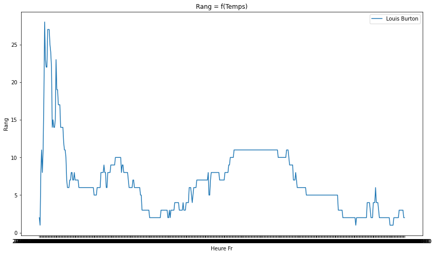

```python
skipper = df_distance["Skipper"].unique()

plt.subplots(figsize=(14, 8))
plt.title("Rang = f(Temps)")


nom = skipper[1]
rang = df_distance['Rang'].loc[(df_distance["Skipper"] == nom)]
dates = df_distance['Heure Fr'].loc[(df_distance["Skipper"] == nom)]
plt.plot(dates, rang, label = nom)

plt.xlabel("Heure Fr")
plt.ylabel("Rang")
plt.legend()
```

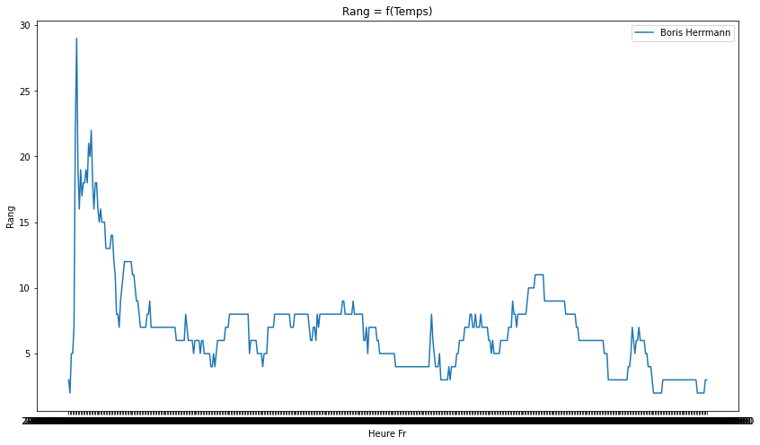

```python
skipper = df_distance["Skipper"].unique()

plt.subplots(figsize=(14, 8))
plt.title("Rang = f(Temps)")


nom = skipper[2]
rang = df_distance['Rang'].loc[(df_distance["Skipper"] == nom)]
dates = df_distance['Heure Fr'].loc[(df_distance["Skipper"] == nom)]
plt.plot(dates, rang, label = nom)

plt.xlabel("Heure Fr")
plt.ylabel("Rang")
plt.legend()
```

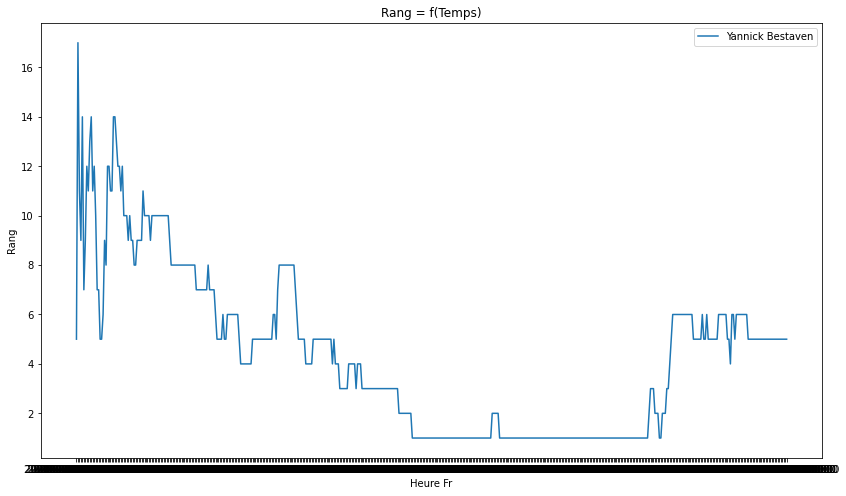

```python
skipper = df_distance["Skipper"].unique()

plt.subplots(figsize=(14, 8))
plt.title("Rang = f(Temps)")


nom = skipper[3]
rang = df_distance['Rang'].loc[(df_distance["Skipper"] == nom)]
dates = df_distance['Heure Fr'].loc[(df_distance["Skipper"] == nom)]
plt.plot(dates, rang, label = nom)

plt.xlabel("Heure Fr")
plt.ylabel("Rang")
plt.legend()
```

## 5) Visualisation de la distance parcourue par voilier

```python
df_distance = pd.read_pickle("./fusion.pkl")
df_distance = df_distance[["Rang","Distance (Last rank) en nm","Skipper"]]
df_distance["Distance (Last rank) en nm"] = df_distance["Distance (Last rank) en nm"].apply(lambda x: float(x))
df_distance = df_distance[['Skipper',"Distance (Last rank) en nm"]].groupby(['Skipper']).sum(["Distance (Last rank) en nm","Skipper"])
df_distance
```

| Skipper | Distance (Last rank) en nm |
| --- | --- |
| Alan Roura | 26343.6 |
| Alex Thomson | 11075.3 |
| Alexia Barrier | 22966.4 |
| Ari Huusela | 23545.7 |
| Armel Tripon | 29247.6 |
| Arnaud Boissieres | 26304.4 |
| Benjamin Dutreux | 29416.0 |
| Boris Herrmann | 30287.7 |
| Charlie Dalin | 30834.5 |
| Clarisse Cremer | 27860.8 |
| Clément Giraud | 24931.7 |
| Damien Seguin | 29379.6 |
| Didac Costa | 25852.9 |
| Fabrice Amedeo | 11193.2 |
| Giancarlo Pedote | 29975.2 |
| Isabelle Joschke | 23440.1 |
| Jean Le Cam | 29289.4 |
| Jérémie Beyou | 28588.0 |
| Kevin Escoffier | 10398.1 |
| Kojiro Shiraishi | 26612.4 |
| Louis Burton | 30503.1 |
| Manuel Cousin | 25570.3 |
| Maxime Sorel | 28702.4 |
| Miranda Merron | 24622.5 |
| Pip Hare | 25640.1 |
| Romain Attanasio | 26995.4 |
| Samantha Davies | 11398.9 |
| Stéphane Le Diraison | 26404.8 |
| Sébastien Destremau | 18500.2 |
| Sébastien Simon | 11428.6 |
| Yannick Bestaven | 30269.1 |

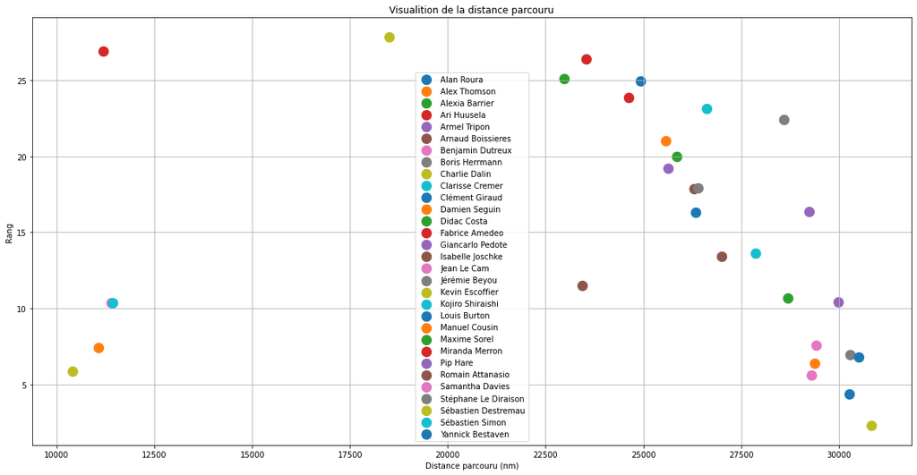

```python
Rank = df_fusion_3_calcul["Rang"].to_numpy()
distance = df_distance.to_numpy()
Skippers = list(df_distance.index)

plt.subplots(figsize=(20, 10))
plt.title("Visualition de la distance parcouru")

for k in range(len(Skippers)):
    plt.scatter(distance[k],Rank[k],s = 150, label = Skippers[k])

plt.xlabel("Distance parcouru (nm)")
plt.ylabel("Rang")
plt.grid()
plt.legend()
```